# Genome Wide Association Studies with treeWAS

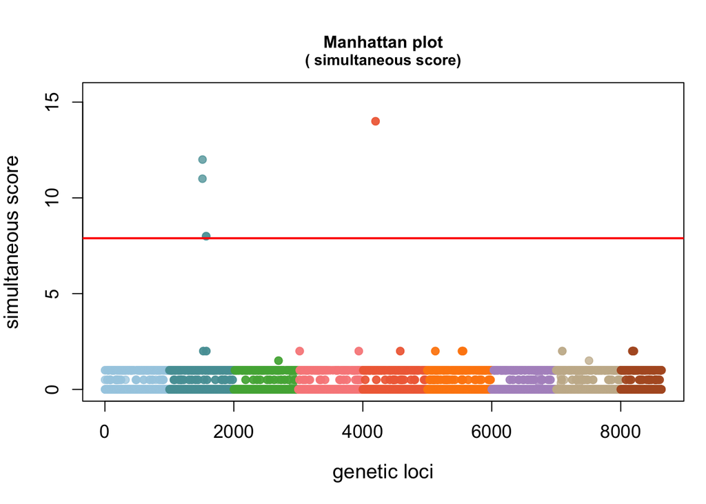

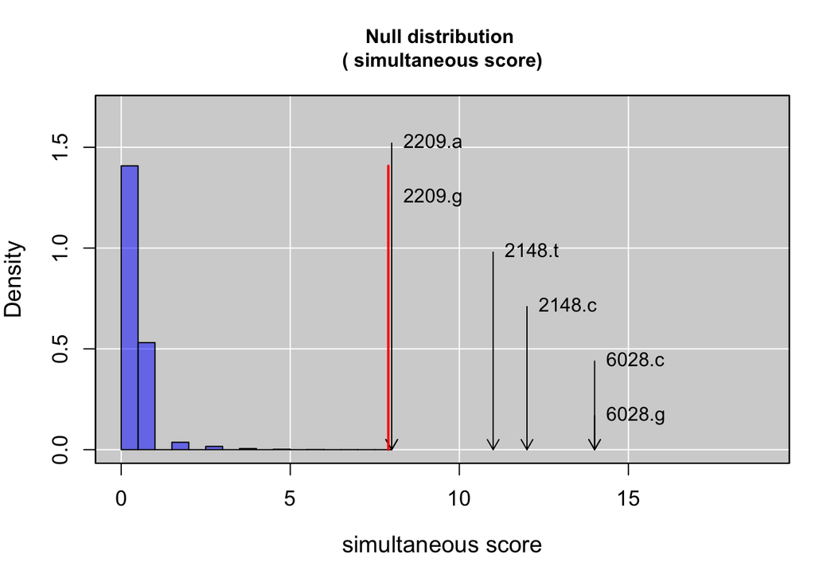

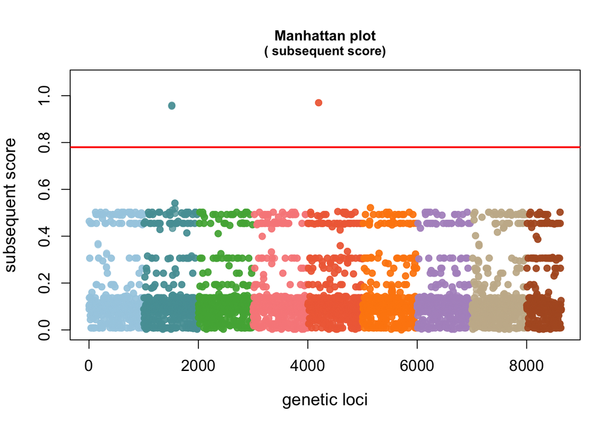

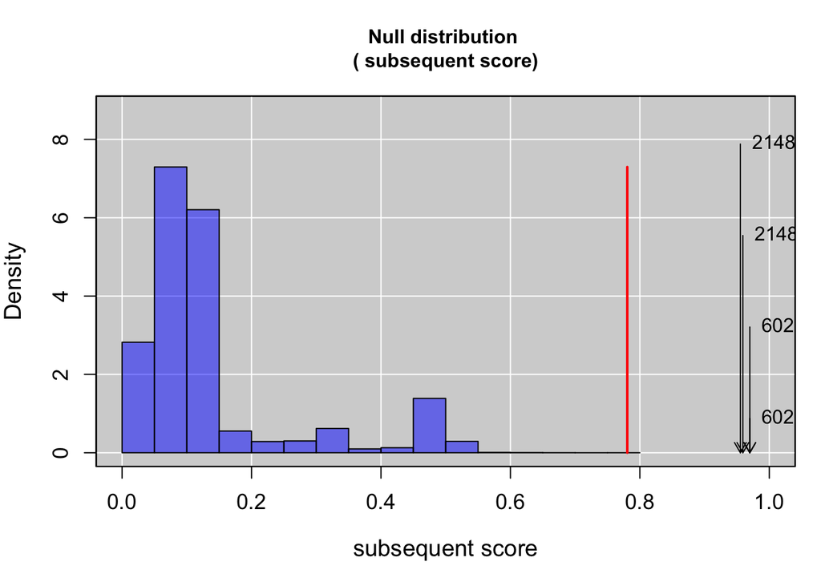

#### The results will show you the coordinates in the genotype file that have been found to be significantly associated with the phenotype.

#### Exercise: You have been provided with an index file “TB_Moldova_index.txt” which will enable you to link the coordinates in the genotype file to their position in the TB H37Rv reference strain. Find the genes that harbour the significant SNPs, what do you think the phenotype is in our analysis?

*Tip: Go back to the NCBI tutorial on the first day to see how to view reference strains.*

### This is the end of practical 4. Navigate back to the homepage [here](https://bensobkowiak.github.io/GenomicsCourse/)